# Euromart1_EDA

```python
import pandas as pd
import numpy as np
import matplotlib.pyplot as plt
import datetime
import plotly.express as px
import plotly.graph_objects as go
from plotly.subplots import make_subplots
```

## Loading Data:

The Pandas library offers a wide range of possibilities for loading data into the pandas DataFrame from files like JSON, .csv, .xlsx, .sql, .pickle, .html, .txt, images etc.

```python
df = pd.read_excel(r"C:\\Users\\jyoth\\OneDrive\\Documents\\Euromart\\EuroMart_Stores_RETAIL_DATA.xlsx")
```

### **Reading Data**

Analyzing the Data

Before we make any inferences, we listen to our data by examining all variables in the data.

The main goal of data understanding is to gain general insights about the data, which covers the number of rows and columns, values in the data, datatypes, and Missing values in the dataset.

head() will display the top 5 observations of the dataset

```python
df.head()
```

|  | Order ID | Order Date | Customer Name | Country | State | City | Region | Segment | Ship Mode | Category | Sub-Category | Product Name | Discount | Sales | Profit | Quantity | Feedback? |
| --- | --- | --- | --- | --- | --- | --- | --- | --- | --- | --- | --- | --- | --- | --- | --- | --- | --- |
| 0 | BN-2011-7407039 | 2011-01-01 | Ruby Patel | Sweden | Stockholm | Stockholm | North | Home Office | Economy Plus | Office Supplies | Paper | Enermax Note Cards, Premium | 0.5 | 45 | -26 | 3 | False |
| 1 | AZ-2011-9050313 | 2011-01-03 | Summer Hayward | United Kingdom | England | Southport | North | Consumer | Economy | Furniture | Bookcases | Dania Corner Shelving, Traditional | 0.0 | 854 | 290 | 7 | True |
| 2 | AZ-2011-6674300 | 2011-01-04 | Devin Huddleston | France | Auvergne-Rhône-Alpes | Valence | Central | Consumer | Economy | Office Supplies | Art | Binney & Smith Sketch Pad, Easy-Erase | 0.0 | 140 | 21 | 3 | True |
| 3 | BN-2011-2819714 | 2011-01-04 | Mary Parker | United Kingdom | England | Birmingham | North | Corporate | Economy | Office Supplies | Art | Boston Markers, Easy-Erase | 0.5 | 27 | -22 | 2 | True |
| 4 | BN-2011-2819714 | 2011-01-04 | Mary Parker | United Kingdom | England | Birmingham | North | Corporate | Economy | Office Supplies | Storage | Eldon Folders, Single Width | 0.5 | 17 | -1 | 2 | True |

**tail()** will display the last 5 observations of the dataset

```python
df.tail()
```

|  | Order ID | Order Date | Customer Name | Country | State | City | Region | Segment | Ship Mode | Category | Sub-Category | Product Name | Discount | Sales | Profit | Quantity | Feedback? |
| --- | --- | --- | --- | --- | --- | --- | --- | --- | --- | --- | --- | --- | --- | --- | --- | --- | --- |
| 8042 | AZ-2014-766953 | 2014-12-31 | Jose Gambino | United Kingdom | England | Maidenhead | North | Corporate | Economy | Furniture | Bookcases | Ikea Stackable Bookrack, Traditional | 0.0 | 245 | 91 | 2 | True |
| 8043 | BN-2014-4140795 | 2014-12-31 | Daniel Hamilton | Netherlands | North Brabant | Eindhoven | Central | Home Office | Economy Plus | Office Supplies | Art | BIC Pencil Sharpener, Fluorescent | 0.5 | 30 | -10 | 2 | False |
| 8044 | BN-2014-4140795 | 2014-12-31 | Daniel Hamilton | Netherlands | North Brabant | Eindhoven | Central | Home Office | Economy Plus | Office Supplies | Binders | Avery Binder Covers, Recycled | 0.5 | 23 | -6 | 4 | True |
| 8045 | BN-2014-4140795 | 2014-12-31 | Daniel Hamilton | Netherlands | North Brabant | Eindhoven | Central | Home Office | Economy Plus | Technology | Machines | StarTech Phone, Red | 0.5 | 108 | -19 | 3 | False |
| 8046 | AZ-2014-766953 | 2014-12-31 | Jose Gambino | United Kingdom | England | Maidenhead | North | Corporate | Economy | Technology | Phones | Motorola Audio Dock, VoIP | 0.0 | 867 | 251 | 5 | False |

```python
df.shape
```

```
(8047, 17)
```

shape – shape will display the number of observations(rows) and features(columns) in the dataset

There are 8047 observations and 17 variables in our dataset

```python
df.columns
```

```
Index(['Order ID', 'Order Date', 'Customer Name', 'Country', 'State', 'City',
       'Region', 'Segment', 'Ship Mode', 'Category', 'Sub-Category',
       'Product Name', 'Discount', 'Sales', 'Profit', 'Quantity', 'Feedback?'],
      dtype='object')
```

**info()** helps to understand the data type and information about data, including the number of records in each column, data having null or not null, Data type, the memory usage of the dataset

```python
df.info()
```

```
<class 'pandas.core.frame.DataFrame'>
RangeIndex: 8047 entries, 0 to 8046
Data columns (total 17 columns):
 #   Column         Non-Null Count  Dtype
---  ------         --------------  -----
 0   Order ID       8047 non-null   object
 1   Order Date     8047 non-null   datetime64[ns]
 2   Customer Name  8047 non-null   object
 3   Country        8047 non-null   object
 4   State          8047 non-null   object
 5   City           8047 non-null   object
 6   Region         8047 non-null   object
 7   Segment        8047 non-null   object
 8   Ship Mode      8047 non-null   object
 9   Category       8047 non-null   object
 10  Sub-Category   8047 non-null   object
 11  Product Name   8047 non-null   object
 12  Discount       8047 non-null   float64
 13  Sales          8047 non-null   int64
 14  Profit         8047 non-null   int64
 15  Quantity       8047 non-null   int64
 16  Feedback?      8047 non-null   bool
dtypes: bool(1), datetime64[ns](1), float64(1), int64(3), object(11)
memory usage: 1013.9+ KB
```

### **Finding The Missing Values**

**Check for Duplication**

nunique() based on several unique values in each column and the data description, we can identify the continuous and categorical columns in the data. Duplicated data can be handled or removed based on further analysis

```python
df.isnull().sum()
```

```
Order ID         0
Order Date       0
Customer Name    0
Country          0
State            0
City             0
Region           0
Segment          0
Ship Mode        0
Category         0
Sub-Category     0
Product Name     0
Discount         0
Sales            0
Profit           0
Quantity         0
Feedback?        0
dtype: int64
```

There is no missing values in the dataset.

```python
df.duplicated().sum()
```

```
2
```

```python
df[df.duplicated()]
```

|  | Order ID | Order Date | Customer Name | Country | State | City | Region | Segment | Ship Mode | Category | Sub-Category | Product Name | Discount | Sales | Profit | Quantity | Feedback? |
| --- | --- | --- | --- | --- | --- | --- | --- | --- | --- | --- | --- | --- | --- | --- | --- | --- | --- |
| 2543 | AZ-2012-5907386 | 2012-08-29 | Louie Knight | Belgium | Antwerp | Mechelen | Central | Consumer | Economy | Office Supplies | Art | Sanford Pens, Fluorescent | 0.0 | 37 | 10 | 3 | False |
| 4066 | AZ-2013-5637964 | 2013-06-14 | Cynthia Zielinski | Spain | Madrid | Madrid | South | Home Office | Economy | Office Supplies | Binders | Wilson Jones 3-Hole Punch, Economy | 0.0 | 84 | 28 | 3 | True |

```python
df.duplicated().sum()
```

```
2
```

### **Data Reduction**

#### **Handling Missing Values**

```python
df.drop_duplicates(inplace=True)
```

```python
df.duplicated().sum()
```

```
0
```

#### **Removing unnecessary Columns**

Some columns or variables can be dropped if they do not add value to our analysis.

In our dataset, the column Order ID have only ID values, assuming they don’t have any predictive power to predict the dependent variable.

```python
df.drop('Order ID', axis=1, inplace=True)
```

```python
df.head()
```

|  | Order Date | Customer Name | Country | State | City | Region | Segment | Ship Mode | Category | Sub-Category | Product Name | Discount | Sales | Profit | Quantity | Feedback? |
| --- | --- | --- | --- | --- | --- | --- | --- | --- | --- | --- | --- | --- | --- | --- | --- | --- |
| 0 | 2011-01-01 | Ruby Patel | Sweden | Stockholm | Stockholm | North | Home Office | Economy Plus | Office Supplies | Paper | Enermax Note Cards, Premium | 0.5 | 45 | -26 | 3 | False |
| 1 | 2011-01-03 | Summer Hayward | United Kingdom | England | Southport | North | Consumer | Economy | Furniture | Bookcases | Dania Corner Shelving, Traditional | 0.0 | 854 | 290 | 7 | True |
| 2 | 2011-01-04 | Devin Huddleston | France | Auvergne-Rhône-Alpes | Valence | Central | Consumer | Economy | Office Supplies | Art | Binney & Smith Sketch Pad, Easy-Erase | 0.0 | 140 | 21 | 3 | True |
| 3 | 2011-01-04 | Mary Parker | United Kingdom | England | Birmingham | North | Corporate | Economy | Office Supplies | Art | Boston Markers, Easy-Erase | 0.5 | 27 | -22 | 2 | True |
| 4 | 2011-01-04 | Mary Parker | United Kingdom | England | Birmingham | North | Corporate | Economy | Office Supplies | Storage | Eldon Folders, Single Width | 0.5 | 17 | -1 | 2 | True |

### **Creating New columns**

If we see the sample data, the column “Order Date” shows the sale date.

It would be difficult to find the Year & Month wise Sales and Profit.

Introducing a new column, 'Year' , 'Month' to know the sales and Profit distribution on various datetime.

```python
df['Year'] = pd.DatetimeIndex(df['Order Date']).year #df['Order Date'].datetime.year
df['Month'] = pd.DatetimeIndex(df['Order Date']).month
```

```python
df['Discount'] = df['Discount']*100
df['Discount'].astype('int')
```

```
0       50
1        0
2        0
3       50
4       50
        ..
8042     0
8043    50
8044    50
8045    50
8046     0
Name: Discount, Length: 8047, dtype: int32
```

```python
df['Total_sales'] = df['Sales'] * df['Quantity']
df['Total_profit'] = df['Profit'] * df['Quantity']
```

```python
df.head()
```

|  | Order Date | Customer Name | Country | State | City | Region | Segment | Ship Mode | Category | Sub-Category | Product Name | Discount | Sales | Profit | Quantity | Feedback? | Year | Month | Total_sales | Total_profit |
| --- | --- | --- | --- | --- | --- | --- | --- | --- | --- | --- | --- | --- | --- | --- | --- | --- | --- | --- | --- | --- |
| 0 | 2011-01-01 | Ruby Patel | Sweden | Stockholm | Stockholm | North | Home Office | Economy Plus | Office Supplies | Paper | Enermax Note Cards, Premium | 50.0 | 45 | -26 | 3 | False | 2011 | 1 | 135 | -78 |
| 1 | 2011-01-03 | Summer Hayward | United Kingdom | England | Southport | North | Consumer | Economy | Furniture | Bookcases | Dania Corner Shelving, Traditional | 0.0 | 854 | 290 | 7 | True | 2011 | 1 | 5978 | 2030 |
| 2 | 2011-01-04 | Devin Huddleston | France | Auvergne-Rhône-Alpes | Valence | Central | Consumer | Economy | Office Supplies | Art | Binney & Smith Sketch Pad, Easy-Erase | 0.0 | 140 | 21 | 3 | True | 2011 | 1 | 420 | 63 |
| 3 | 2011-01-04 | Mary Parker | United Kingdom | England | Birmingham | North | Corporate | Economy | Office Supplies | Art | Boston Markers, Easy-Erase | 50.0 | 27 | -22 | 2 | True | 2011 | 1 | 54 | -44 |
| 4 | 2011-01-04 | Mary Parker | United Kingdom | England | Birmingham | North | Corporate | Economy | Office Supplies | Storage | Eldon Folders, Single Width | 50.0 | 17 | -1 | 2 | True | 2011 | 1 | 34 | -2 |

We have done the fundamental data analysis, Featuring, and data clean-up. Let’s move to the EDA process

### **EDA Exploratory Data Analysis**

Exploratory Data Analysis refers to the crucial process of performing initial investigations on data to discover patterns to check assumptions with the help of summary statistics and graphical representations.

- EDA can be leveraged to check for outliers, patterns, and trends in the given data.
- EDA helps to find meaningful patterns in data.
- EDA provides in-depth insights into the data sets to solve our business problems.
- EDA gives a clue to impute missing values in the dataset

### **Statistics Summary**

The information gives a quick and simple description of the data.

Can include Count, Mean, Standard Deviation, median, mode, minimum value, maximum value, range, standard deviation, etc.

Statistics summary gives a high-level idea to identify whether the data has any outliers, data entry error, distribution of data such as the data is normally distributed or left/right skewed

In python, this can be achieved using describe()

describe() function gives all statistics summary of data

describe()– Provide a statistics summary of data belonging to numerical datatype such as int, float

```python
df.describe().T
```

|  | count | mean | min | 25% | 50% | 75% | max | std |
| --- | --- | --- | --- | --- | --- | --- | --- | --- |
| Order Date | 8047 | 2013-04-19 12:25:40.748104704 | 2011-01-01 00:00:00 | 2012-06-08 00:00:00 | 2013-06-11 00:00:00 | 2014-04-30 00:00:00 | 2014-12-31 00:00:00 | NaN |
| Discount | 8047.0 | 11.004722 | 0.0 | 0.0 | 0.0 | 10.0 | 85.0 | 18.177262 |
| Sales | 8047.0 | 291.845657 | 3.0 | 48.0 | 117.0 | 313.0 | 6517.0 | 485.212156 |
| Profit | 8047.0 | 35.198211 | -3060.0 | 1.0 | 14.0 | 47.0 | 2476.0 | 178.125844 |
| Quantity | 8047.0 | 3.772089 | 1.0 | 2.0 | 3.0 | 5.0 | 14.0 | 2.203369 |
| Year | 8047.0 | 2012.728843 | 2011.0 | 2012.0 | 2013.0 | 2014.0 | 2014.0 | 1.100264 |
| Month | 8047.0 | 7.365229 | 1.0 | 5.0 | 8.0 | 10.0 | 12.0 | 3.321485 |
| Total_sales | 8047.0 | 1478.685597 | 3.0 | 127.5 | 413.0 | 1273.0 | 80206.0 | 3725.809433 |
| Total_profit | 8047.0 | 171.491736 | -36720.0 | 1.0 | 40.0 | 181.0 | 29712.0 | 1325.429134 |

```python
df.describe(include='object')
```

|  | Customer Name | Country | State | City | Region | Segment | Ship Mode | Category | Sub-Category | Product Name |
| --- | --- | --- | --- | --- | --- | --- | --- | --- | --- | --- |
| count | 8047 | 8047 | 8047 | 8047 | 8047 | 8047 | 8047 | 8047 | 8047 | 8047 |
| unique | 792 | 15 | 127 | 999 | 3 | 3 | 4 | 3 | 17 | 1810 |
| top | Joel Peters | France | England | London | Central | Consumer | Economy | Office Supplies | Art | Eldon File Cart, Single Width |
| freq | 32 | 1916 | 1187 | 219 | 4426 | 4174 | 4862 | 5286 | 1152 | 26 |

Discount Analysis: The average discount applied to orders is approximately 11%, with a minimum of 0% and a maximum of 85%.

Sales Performance: The average sales amount per order is ₹291.90. Sales vary widely, with the lowest recorded sale being ₹3.00 and the highest reaching ₹6517.00.

Profit Analysis: The average profit per order is ₹35.20. However, there are instances of losses, with the lowest recorded profit being -₹3060.00. This indicates potential areas for improvement in cost management or pricing strategies.

```python
df['State'].value_counts().head(10)
```

```
State
England                               1187
Ile-de-France                          673
North Rhine-Westphalia                 572
Provence-Alpes-Côte d'Azur             250
Madrid                                 199
Vienna                                 196
Berlin                                 177
Languedoc-Roussillon-Midi-Pyrénées     172
Auvergne-Rhône-Alpes                   170
Stockholm                              153
Name: count, dtype: int64
```

#### **1.Net Sales**

```python
net_sales = df['Sales'].sum()
print('The total net sales amount र',net_sales)
```

```
The total net sales amount र 2348361
```

#### **2.Net Profit**

```python
net_profit = df['Profit'].sum()
print('The total net Profit amount : र',net_profit)
```

```
The total net Profit amount : र 283202
```

```python
profit_percentage = (net_profit/net_sales) * 100
print(f"The profit margin stands at {profit_percentage:.2f} % of the total net sales.")
```

```
The profit margin stands at 12.06 % of the total net sales.
```

#### **3.Which country has the highest sales, and which has the highest profit?**

```python
country_sales = df.groupby('Country')[['Sales', 'Profit']].sum().sort_values(by=['Sales','Profit'], ascending=False).style.background_gradient(cmap='PuBu')
country_sales
```

| Country | Sales | Profit |
| --- | --- | --- |
| France | 609683 | 70067 |
| Germany | 488681 | 86279 |
| United Kingdom | 420497 | 90382 |
| Italy | 252742 | 15802 |
| Spain | 249318 | 47039 |
| Austria | 79382 | 21332 |
| Netherlands | 70313 | -37188 |
| Belgium | 42283 | 9902 |
| Sweden | 30490 | -17524 |
| Switzerland | 24874 | 7234 |
| Finland | 20702 | 3908 |
| Norway | 20529 | 5167 |
| Ireland | 15998 | -6886 |
| Portugal | 15106 | -8704 |
| Denmark | 7763 | -3608 |

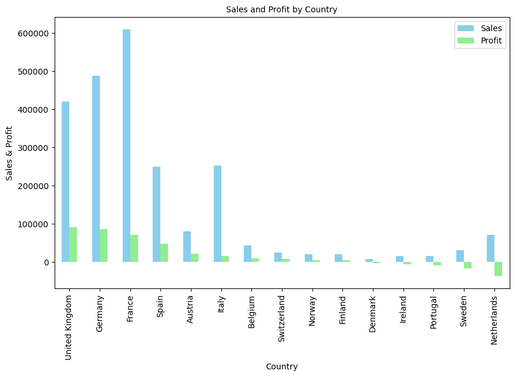

```python
df.groupby('Country')[['Sales', 'Profit']].sum().sort_values(by=['Profit','Sales'], ascending=False).plot.bar(figsize=(10, 6),fontsize=10, color=['skyblue', 'lightgreen'])
plt.title("Sales and Profit by Country", fontsize=10)
plt.xlabel("Country")
plt.ylabel("Sales & Profit")

plt.show()
```

- Top Performers: France, Germany, and the United Kingdom stand out as the top performers in both sales and profit.
- Profitable Markets: These countries, along with Italy and Spain, demonstrate significant profits despite varying sales volumes.
- Challenges: Some countries, such as Sweden, Ireland, Portugal, and Denmark, face challenges with sales and profitability, with losses incurred in their operations.
- Mixed Results: Countries like Austria, Switzerland, and Finland show moderate sales figures with varying levels of profitability.
- Netherlands' Losses: Notably, the Netherlands experienced a loss despite achieving considerable sales, indicating potential issues with cost management or pricing strategies.

#### **4.Which State has the highest sales, and which has the highest profit?**

```python
df.groupby('State')[['Sales', 'Profit']].sum().sort_values(by=['Sales','Profit'], ascending=False).head(10).style.background_gradient(cmap='PuBu')
```

| State | Sales | Profit |
| --- | --- | --- |
| England | 378984 | 79069 |
| Ile-de-France | 230138 | 29457 |
| North Rhine-Westphalia | 170233 | 32572 |
| Provence-Alpes-Côte d'Azur | 81524 | 11615 |
| Madrid | 57207 | 13273 |
| Auvergne-Rhône-Alpes | 55572 | 9283 |
| Berlin | 52555 | 5942 |
| Nord-Pas-de-Calais-Picardie | 52007 | 5207 |
| Vienna | 51844 | 13207 |
| Bavaria | 49103 | 9490 |

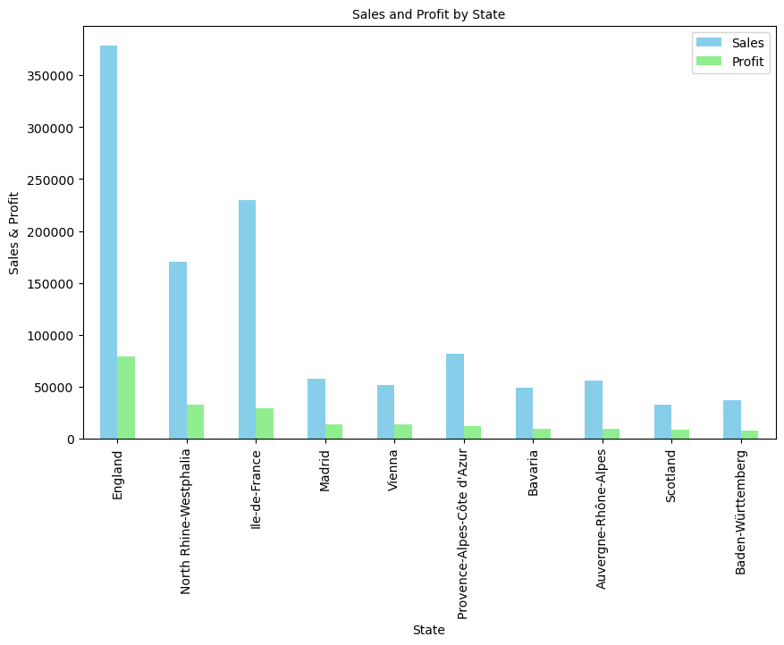

```python
df.groupby('State')[['Sales', 'Profit']].sum().sort_values(by=['Profit','Sales'], ascending=False).head(10).plot.bar(figsize=(10, 6), fontsize=10, color=['skyblue', 'lightgreen'])
plt.title("Sales and Profit by State", fontsize=10)
plt.xlabel("State")
plt.ylabel("Sales & Profit")
plt.show()
```

#### **5.Which City has the highest sales, and which has the highest profit?**

```python
df.groupby('City')[['Sales', 'Profit']].sum().sort_values(by=['Sales','Profit'], ascending=False).head(10).style.background_gradient(cmap='PuBu')
```

| City | Sales | Profit |
| --- | --- | --- |
| London | 69230 | 13931 |
| Berlin | 52555 | 5942 |
| Vienna | 51844 | 13207 |
| Madrid | 44981 | 11129 |
| Paris | 42245 | 6680 |
| Rome | 28330 | 191 |
| Barcelona | 27405 | 2246 |
| Hamburg | 23574 | 5858 |
| Marseille | 21677 | 2889 |
| Turin | 19829 | 1937 |

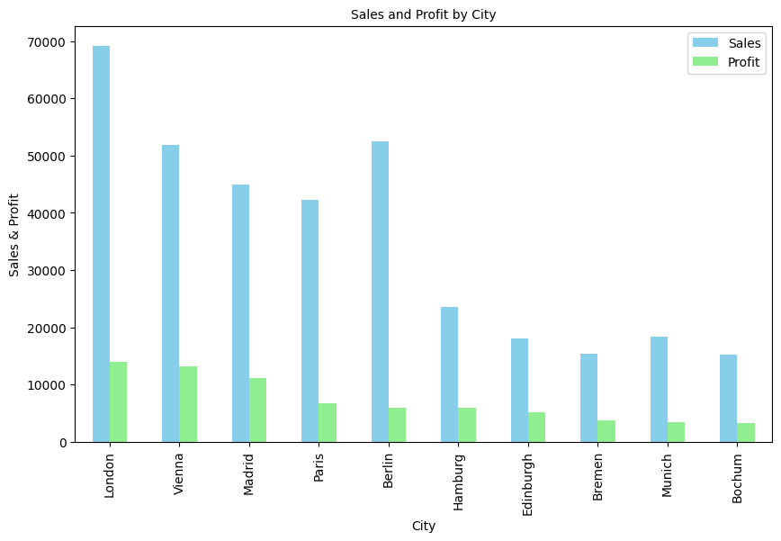

```python
df.groupby('City')[['Sales', 'Profit']].sum().sort_values(by=['Profit','Sales'], ascending=False).head(10).plot.bar(figsize=(10, 6), fontsize=10, color=['skyblue', 'lightgreen'])
plt.title("Sales and Profit by City", fontsize=10)
plt.xlabel("City")
plt.ylabel("Sales & Profit")
plt.show()
```

- London Leading: London emerges as the top performer in both sales and profit, showcasing strong market activity.
- Vienna's Profitability: Vienna demonstrates a high profit margin despite slightly lower sales compared to London, indicating efficient operations or pricing strategies.
- Challenges in Rome: While Rome shows moderate sales, the profit margin is notably low, suggesting potential issues with cost management or pricing strategies in this city.

#### **6.Which Region has the highest sales, and which has the highest profit?**

```python
df.groupby('Region')[['Sales', 'Profit']].sum().sort_values(by=['Sales','Profit'], ascending=False).style.background_gradient(cmap='PuBu')
```

| Region | Sales | Profit |
| --- | --- | --- |
| Central | 1315253 | 157636 |
| South | 517250 | 54165 |
| North | 515979 | 71439 |

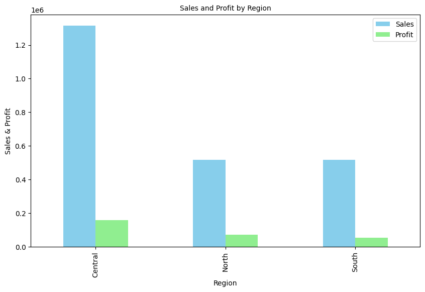

```python
df.groupby('Region')[['Sales', 'Profit']].sum().sort_values(by=['Profit','Sales'], ascending=False).plot.bar(figsize=(10, 6), fontsize=10, color=['skyblue', 'lightgreen'])
plt.title("Sales and Profit by Region", fontsize=10)
plt.xlabel("Region")
plt.ylabel("Sales & Profit")

plt.show()
```

- Central Region Dominance: The Central region leads significantly in both sales and profit, indicating a strong market presence and effective operations.
- Balanced Performance in North and South: While the North and South regions have relatively lower sales compared to the Central region, they still maintain decent profit margins, suggesting balanced performance across different geographical areas.

#### **7.Which Segment contribute the most to sales and profit?**

```python
df.groupby('Segment')[['Sales', 'Profit']].sum().sort_values(by=['Sales','Profit'], ascending=False).style.background_gradient(cmap='Greens')
```

| Segment | Sales | Profit |
| --- | --- | --- |
| Consumer | 1236282 | 147447 |
| Corporate | 738137 | 92634 |
| Home Office | 374063 | 43159 |

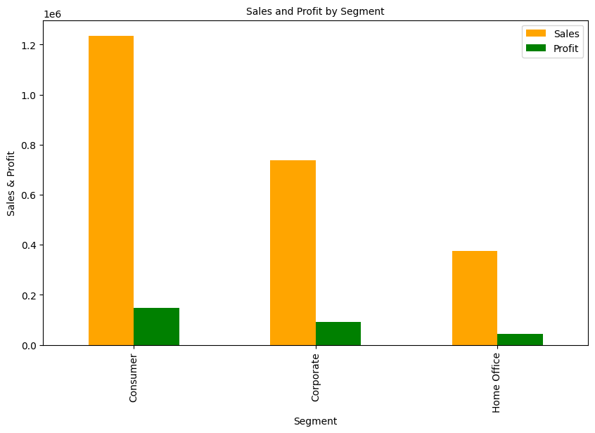

```python
df.groupby('Segment')[['Sales', 'Profit']].sum().sort_values(by=['Profit','Sales'], ascending=False).plot.bar(figsize=(10, 6), fontsize=10, color=['orange', 'green'])
plt.title("Sales and Profit by Segment", fontsize=10)
plt.xlabel("Segment")
plt.ylabel("Sales & Profit")

plt.show()
```

- Consumer Segment Dominance: The consumer segment stands out with the highest sales and profit among all segments, indicating strong demand and profitability.
- Corporate Segment: While the corporate segment follows in terms of sales, it shows a notable profit margin, suggesting efficient operations or pricing strategies.
- Home Office Segment: Although the home office segment has the lowest sales, it still maintains a decent profit margin, contributing to overall profitability.

#### **8.Which Ship Mode contribute the most to sales and profit?**

```python
df.groupby('Ship Mode')[['Sales', 'Profit']].sum().sort_values(by=['Sales','Profit'], ascending=False).style.background_gradient(cmap='Blues')
```

| Ship Mode | Sales | Profit |
| --- | --- | --- |
| Economy | 1412777 | 178696 |
| Economy Plus | 483965 | 54336 |
| Priority | 320426 | 32639 |
| Immediate | 131314 | 17569 |

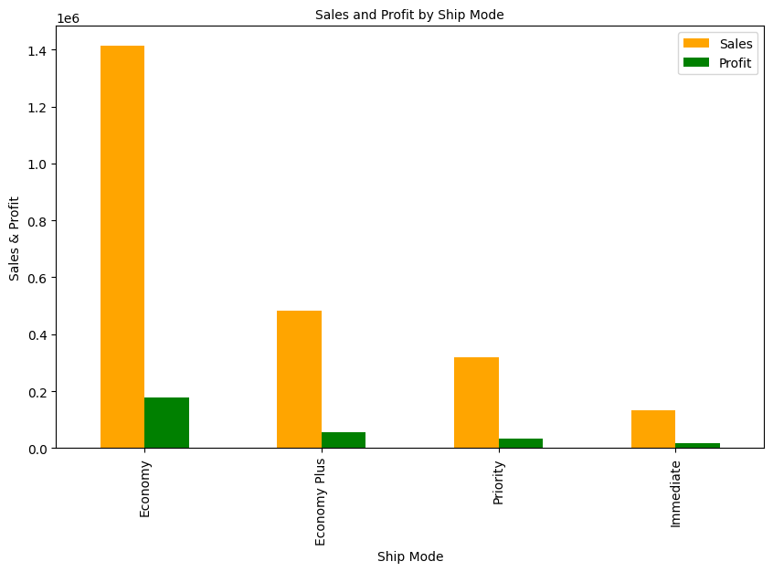

```python
df.groupby('Ship Mode')[['Sales', 'Profit']].sum().sort_values(by=['Profit','Sales'], ascending=False).plot.bar(figsize=(10, 6), fontsize=10, color=['orange', 'green'])
plt.title("Sales and Profit by Ship Mode", fontsize=10)
plt.xlabel("Ship Mode")
plt.ylabel("Sales & Profit")

plt.show()
```

- Economy Ship Mode Dominance: Economy ship mode stands out with the highest sales and profit among all ship modes, indicating its popularity and profitability.
- Economy Plus: While economy plus follows in terms of sales, it still maintains a respectable profit margin, suggesting its significance in the overall revenue generation.
- Priority and Immediate: These ship modes contribute to sales and profit, although they have comparatively lower figures compared to economy and economy plus.

#### **9.Which product categories contribute the most to sales and profit?**

```python
df.groupby('Category')[['Sales', 'Profit']].sum().sort_values(by=['Sales','Profit'], ascending=False).style.background_gradient(cmap='Blues')
```

| Category | Sales | Profit |
| --- | --- | --- |
| Technology | 886015 | 108554 |
| Office Supplies | 823658 | 124952 |
| Furniture | 638809 | 49734 |

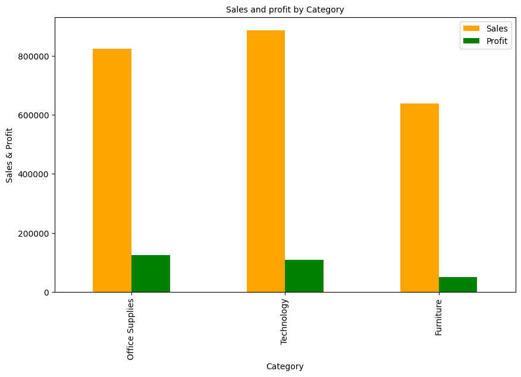

```python
df.groupby('Category')[['Sales', 'Profit']].sum().sort_values(by=['Profit','Sales'], ascending=False).plot.bar(figsize=(10, 6), fontsize=10, color=['orange', 'green'])
plt.title("Sales and profit by Category", fontsize=10)
plt.xlabel("Category")
plt.ylabel("Sales & Profit")

plt.show()
```

- Technology Segment Dominance: Technology emerges as the leading category in terms of sales, closely followed by office supplies.
- Profit Margin: Although office supplies have slightly lower sales compared to technology, they exhibit a higher profit margin, indicating their importance in generating profitability.
- Furniture Segment: While furniture has decent sales figures, its profit margin is comparatively lower, suggesting potential challenges or lower profit margins in this category.

#### **10.Which product categories contribute the most to sales and profit?**

```python
df.groupby('Sub-Category')[['Sales', 'Profit']].sum().sort_values(by=['Sales','Profit'], ascending=False).style.background_gradient(cmap='Blues')
```

| Sub-Category | Sales | Profit |
| --- | --- | --- |
| Bookcases | 294396 | 43655 |
| Copiers | 290081 | 42775 |
| Phones | 282559 | 27631 |
| Storage | 272489 | 21995 |
| Appliances | 209900 | 37906 |
| Chairs | 186698 | 15489 |
| Machines | 182066 | 11318 |
| Accessories | 131309 | 26830 |
| Art | 127184 | 23491 |
| Tables | 89478 | -20731 |
| Binders | 78934 | 14703 |
| Furnishings | 68237 | 11321 |
| Supplies | 38824 | 6853 |
| Paper | 36057 | 7485 |
| Envelopes | 31210 | 6463 |
| Fasteners | 16238 | 3420 |
| Labels | 12822 | 2636 |

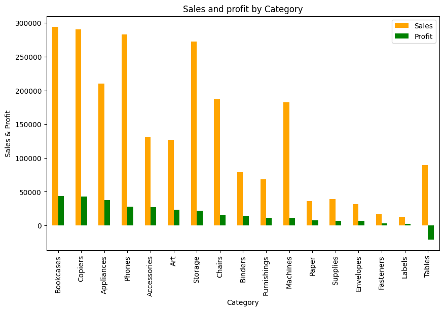

```python
df.groupby('Sub-Category')[['Sales', 'Profit']].sum().sort_values(by=['Profit','Sales'], ascending=False).plot.bar(figsize=(10, 6), color=['orange', 'green'])
plt.title("Sales and profit by Category")
plt.xlabel("Category")
plt.ylabel("Sales & Profit")

plt.show()
```

- Top Performing Sub-Categories: Bookcases and copiers emerge as the top-performing sub-categories, boasting high sales figures and significant profits.
- Profitable Sub-Categories: Despite lower sales volumes, accessories, art, and appliances demonstrate notable profit margins, indicating their importance in generating profitability.
- Challenges in Tables Sub-Category: The tables sub-category shows a negative profit, suggesting potential issues such as high costs or pricing strategies that need attention.